# Multivariate Generalized Additive Models (GAMs)

## Overview of today’s material

- Multivariate models in `mgcv` (Pederson et al. 2019)[https://doi.org/10.7717/peerj.6876]
- Flexible dynamic models with `mvgam` (Clark et al. 2022)[https://doi.org/10.1111/2041-210X.13974]

## Multivariate models in `mgcv`

- Often we have multiple related response variables
- Examples: different locations, species, or strata
- Goal: model shared and individual trends across responses while accounting for correlation and partial pooling

## Multivariate models in `mgcv`

- Lots of ways we can think to model variation by time series
- Different intercepts / trends (harbor seal example in MARSS)
- Site:year random effects (GLMMs)
- Factor smooths (specific to GAMs)

## Introducing factor smooths

- **What is a factor smooth?**
- A factor smooth is a smooth term in a model where a categorical variable interacts with a continuous predictor
- This type of smooth allows modeling of varying relationships between continuous predictors across different levels of a factor

## How do we implement these in `mgcv`?

- Use the `s()` function to specify smooth terms.
- To specify a factor smooth, we include the factor variable in the formula:

```r
gam(response ~ s(predictor, by = factor_variable),
    data = dataset)
```

- When `by = factor`, a separate smooth is estimated for each level

## Comparison with continuous case

- What are the differences in these models?
- s(time, by = x, bs = “cr”)
- s(time, by = location)
- s(time, by = location, bs = “fs”)

## Comparison with continuous case

- s(time, by = x, bs = “cr”)

\[x \cdot f(time)\] - te(time, x) or ti(time, x) become non-linear

## Comparison with continuous case

- What about when `by` is a factor? [Hint: don’t do this!]
- s(time, by = location)
- Unique smooths and penalties per location, location parsed to numeric?

## Comparison with continuous case

- We need to explicitly tell `mgcv` that we want to use a factor smooth
- s(time, by = location, bs = “fs”)
- Unique smooths per location
- penalty is shared across all levels of the factor (same wiggliness)

## Illustrating different models with the harbor seal dataset

```r
data("harborSeal")
long_seal <- as.data.frame(harborSeal) |>
  pivot_longer(cols = starts_with("CoastalEstuaries"):
                 starts_with("Georgia.Strait"),
               names_to = "location",
               values_to = "value")

long_seal$location <- as.factor(long_seal$location)
```

## Three models for comparison

- Model G: global smooth
- Model GS: global smooth, time series - specific smooths
- Model S: time series - specific smooths

## Model G

- Global smooth (shared trend)

```r
fit_G <- gam(value ~ s(Year, k=8, bs="cr"), #<<
           data=long_seal,
           family="gaussian")
```

## Model G fits

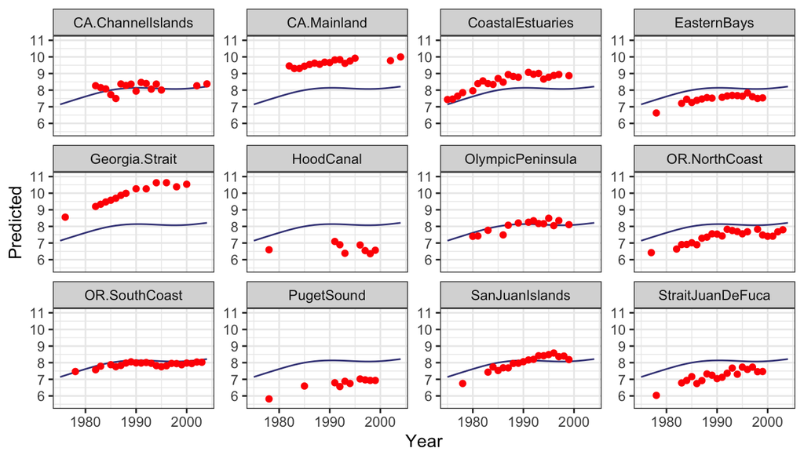

## Model G

- Global smooth (shared trend)
- Time series specific intercepts (n = 12)

```r
fit_G <- gam(value ~ s(Year, k=8, bs="cr") +
             s(location, k=12, bs="re"), #<<
           data=long_seal,
           family="gaussian")
```

## Model G fits

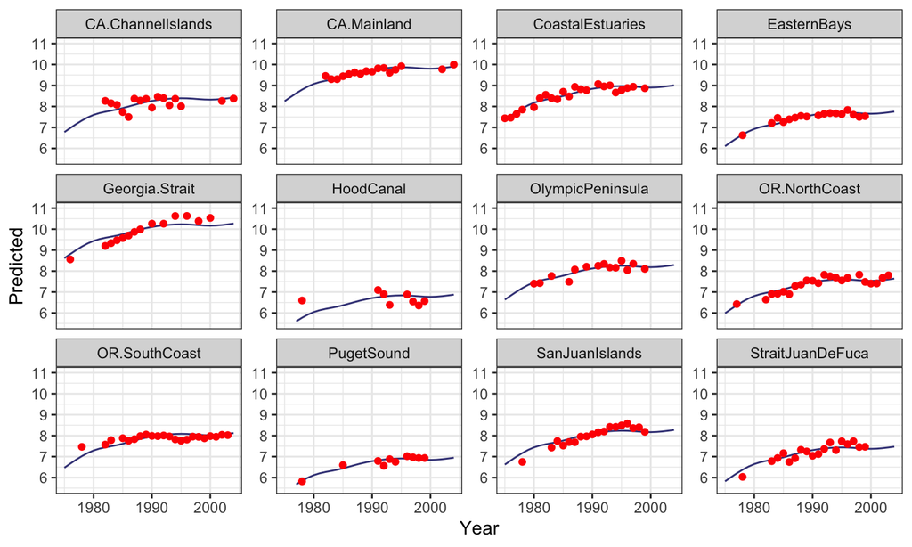

## Model GS

- Global smooth (shared trend)
- Time series specific smooths

```r
fit_GS <- gam(value ~ s(Year, k=8, bs="cr") +
             s(Year, by = location, k = 8, bs="fs") + #<<
               s(location, k=12, bs="re"),
           data=long_seal,
           family="gaussian")
```

## Model GS fits

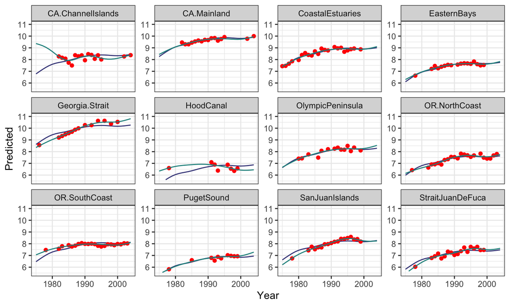

## Model S

- Time series specific smooths
- No global smooth

```r
fit_S <- gam(value ~
             s(Year, by = location, k = 8, bs="fs") +
               s(location, k=12, bs="re"),
           data=long_seal,
           family="gaussian")
```

## Model S fits

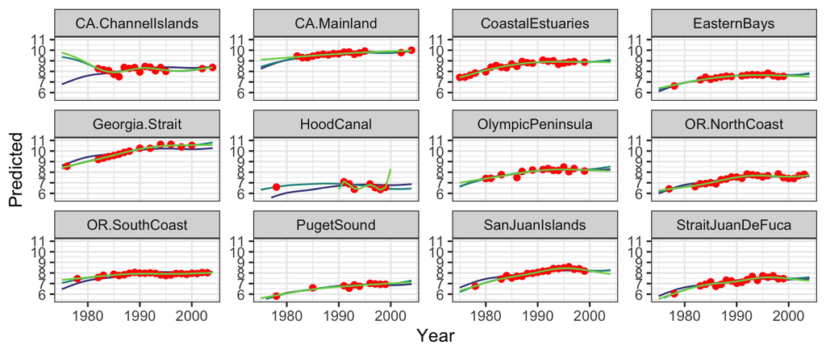

## Comparing fits

```r
print(AIC(fit_G, fit_GS, fit_S))
```

[output not shown]

## Factor Smooths

- Add flexibility for time - series specific smooths
- Similar to MARSS model with either shared (single trend) or MARSS model where each time series is a different trend
- Wiggliness of both global and factor smooths can be specified

## Summarizing these approaches in `mgcv`

- Lots of flexibility
- We could have used `gamm` for additional flexibility in random effects
- Implements mixed models (year:site random effects, etc)

## Transitioning to DGAMs in `mvgam`

- **DGAMs** are an extension of GAMs designed to handle time-varying and dynamic data
- Particularly useful for modeling temporal dependencies / nonlinear relationships
- Can be used with multivariate time series data
- DGAMs incorporate dynamic smooth terms that evolve over time

## Why use DGAMs?

- GAMs are great, but uncertainty blows up as we get further from data (forecast)
- Random walk / AR1 processes also have uncertainty balloon
- DGAMs represent a hybrid approach that can work particularly well for forecasting

## GAM forecast uncertainty

- `y ~ s(t, k = 12)`
- low uncertainty, poor fit

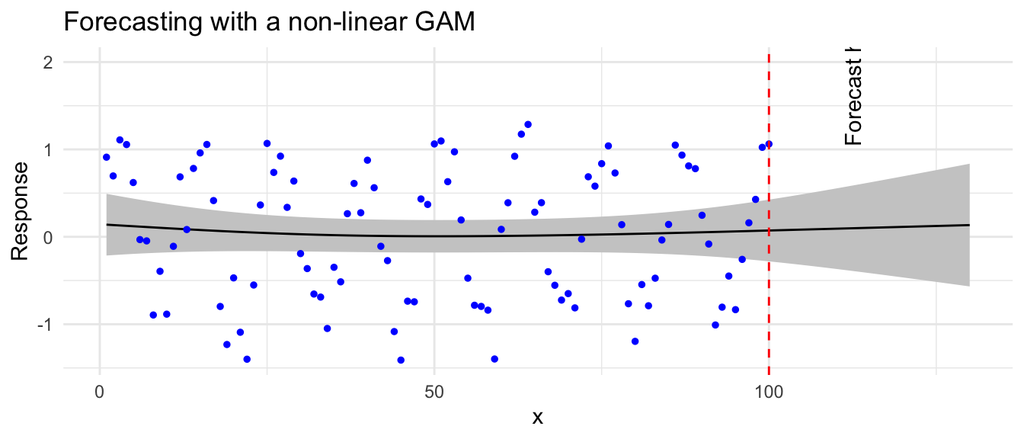

## GAM forecast uncertainty

- `y ~ s(t, k = 50)`
- good fit, high uncertainty

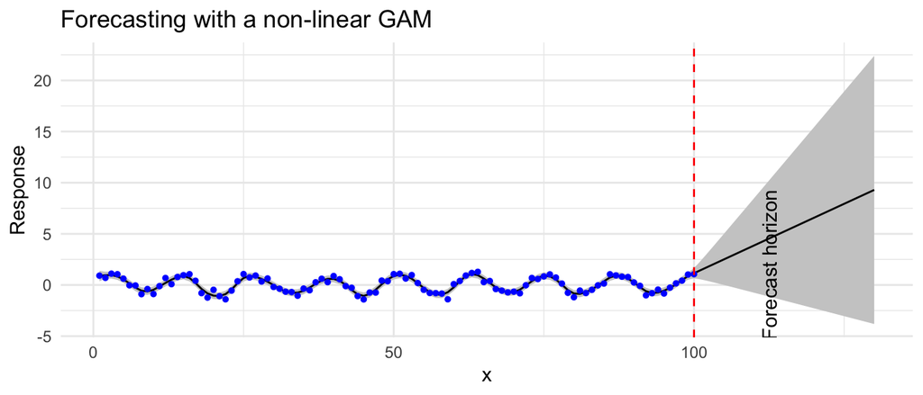

## Mathematically

Remember that GAMs are typically represented as \[ E[Y_t] = \beta_0 + \sum_{i=1}^{I} s(x_{i,t})\] where \(Y_t\) is the response variable at time \(t\), \(\beta_0\) is the intercept, and \(s(x_{i,t})\) are smooth functions of the predictors

## Mathematically

Because the response can be non-Gaussian we use a link function \(g^{=1}()\) to relate the mean of the response to the linear predictor

\[ E[Y_t] = g^{=1} \left( \beta_0 + \sum_{i=1}^{I} s(x_{i,t}) \right)\] where \(g\) is the link function (e.g., logit, log, identity)

## Mathematically

DGAMs add a dynamic component to this equation, allowing for time-varying smooths

\[ E[Y_t] = g^{-1} \left( \beta_0 + \sum_{i=1}^{I} s(x_{i,t}) + z_{t} \right)\] where \(z_{t} = \psi_{0} + \psi_{1}z_{t-1} + \epsilon_t\) and \(\epsilon_t \sim N(0, \sigma_{\epsilon})\) and \(g^{-1}\) is the inverse link function

## Complex latent processes

Random walks can be specified with any dynamic model that we’ve already discussed (AR, MA processes, etc)

\(z_{t} = \psi_{0} + \psi_{1}z_{t-1} + \epsilon_t\)

\(z_{t} = \psi_{0} + \psi_{1}z_{t-1} + \psi_{2}z_{t-2} + \epsilon_t\)

## Dynamic factor processes

For multiple time series, there can be > 1 latent trend, and we can estimate factor loadings (DFA). For time series \(j\)

\[ E[Y_{j,t}] = g^{-1} \left( \beta_0 + \sum_{i=1}^{I} s(x_{i,j,t}) + \sum_{m=1}^{M} z_{m,t}\theta_{j} \right)\]

## The mvgam Package

- The **`mvgam`** package provides tools for fitting DGAMs in R
- Bayesian estimation with Stan backend
- Supports multivariate time series modeling with dynamic smooths
- Provides an interface to easily define dynamic terms in the model

## Simulated data example with `mvgam`

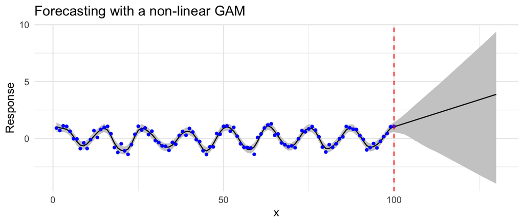

## Harbor seal example with `mvgam`

- Before, we were using factor smooths to model harbor seal trends
- We can fit these exact same models (without trend) in `mvgam`

```r
fit_GS <- mvgam(value ~ s(Year, k=8, bs="cr") +#<<
             s(Year, by = location, k = 8, bs="fs") +
               s(location, k=12, bs="re"),
           data=long_seal,
           family="gaussian", chains = 1)
```

## Plotting the main trend

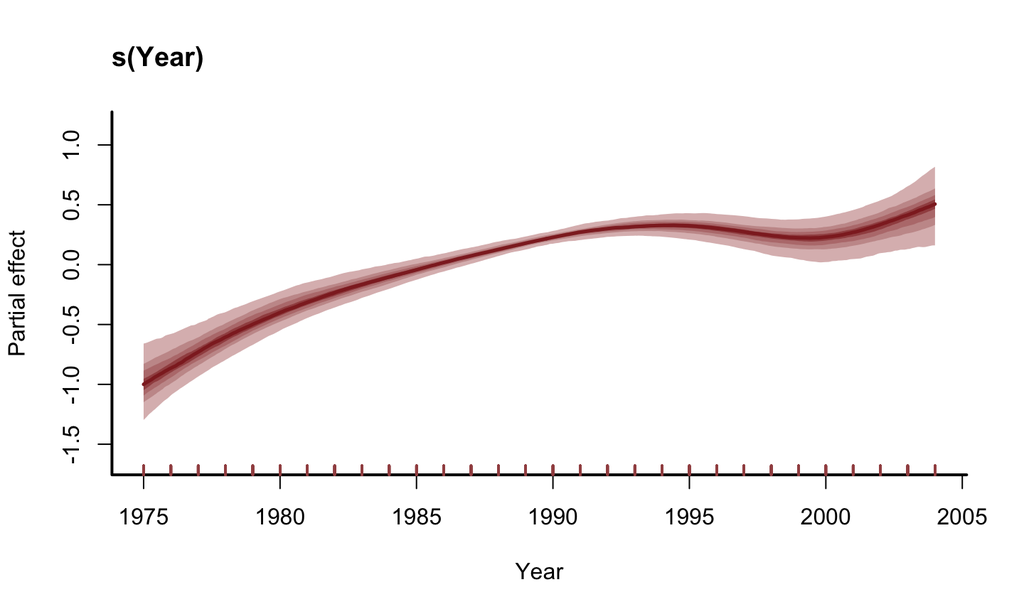

```r
plot_mvgam_smooth(fit_GS)
```

## Including dynamic components: coastal upwelling

*Jacox MG, CA Edwards, EL Hazen, SJ Bograd (2018) Coastal upwelling revisited: Ekman, Bakun, and improved upwelling indices for the U.S. west coast, J. Geophysical Research, 123(10), 7332-7350.*

- CUTI estimates of vertical transport near the coast
- BEUTI estimates of vertical nitrate flux

## Including dynamic components: coastal upwelling

- CUTI collected at monthly time steps
- 1 deg latitude resolution (31 - 47) – we’ll use every other

## Including dynamic components: coastal upwelling

```r
print(head(cuti_long))
```

[output not shown]

## Including dynamic components: coastal upwelling

- for speed, we’ll filter the data to be 2023–2024 (train) and use 2025 for testing

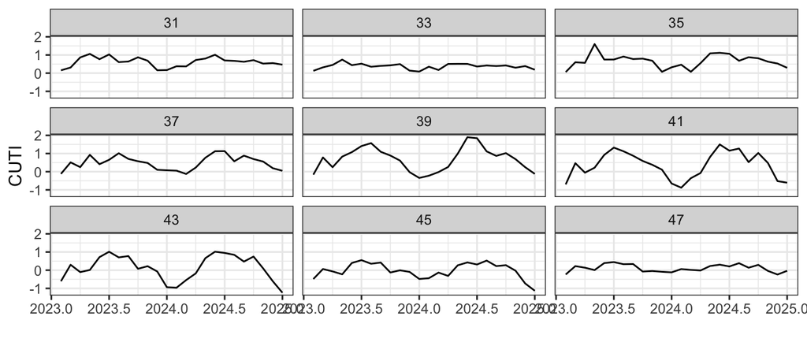

## Including dynamic components: coastal upwelling

- initially no latent trend – what are all the pieces doing??
- estimation is slooooow – so we use data 2023–2025

```r
fit_trend <- mvgam(cuti ~ s(time, bs="cr") +
             s(time, by = latitude, bs="fs") +
               s(latitude, k=9, bs="re") +
                s(month, k = 12, bs="cc"),#<<,
           data=cuti2324,
           share_obs_params = TRUE,#<<,
           family="gaussian", chains = 1)
```

## Including dynamic components: coastal upwelling

- Smooths

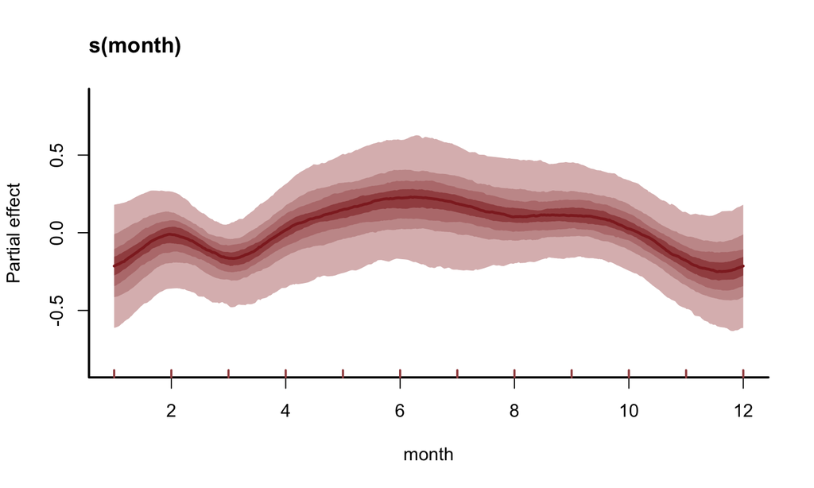

```r
plot_mvgam_smooth(fit_trend, smooth = "month")
```

## Including dynamic components: coastal upwelling

- Time

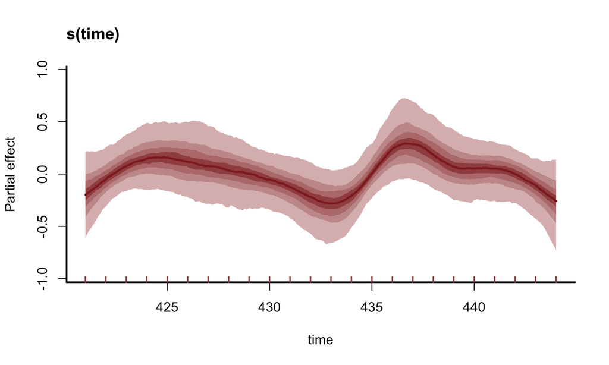

```r
plot_mvgam_smooth(fit_trend, smooth = "time")
```

## Including dynamic components: coastal upwelling

- Predictions (last 3 points are forecasts)

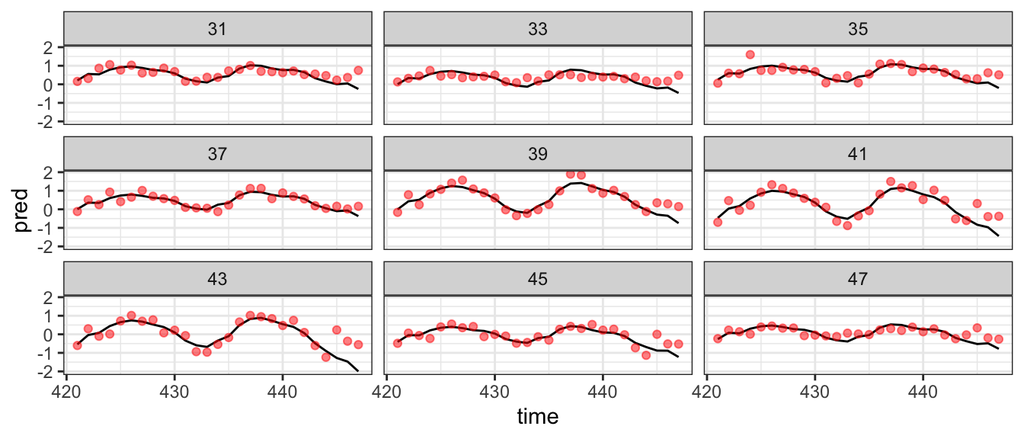

## Including dynamic components: coastal upwelling

- Possibly some problematic residuals (autocorrelated)

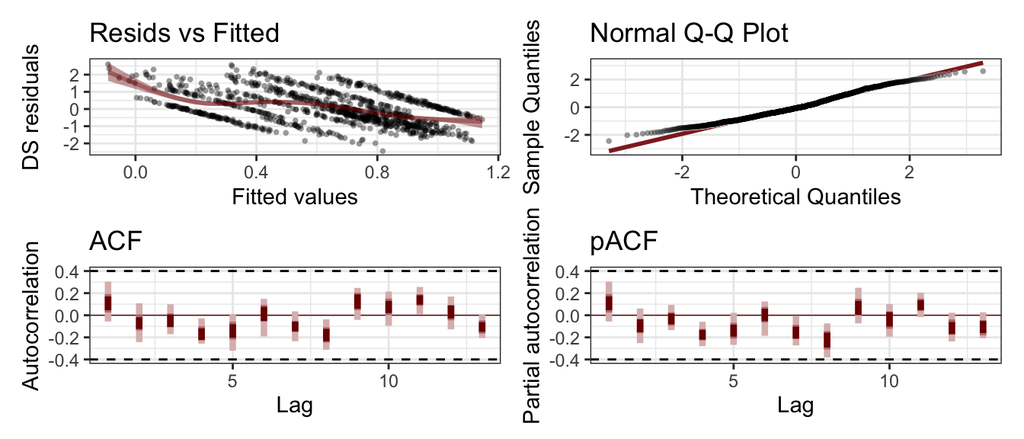

```r
plot(fit_trend)
```

## Including dynamic components: coastal upwelling

- Next we’ll add a trend as a random walk
- By default this is creating a separate trend for each time series
- May have too many competing smooths etc

```r
fit_trend_rw <- mvgam(cuti ~ s(time, bs="cr") +
             s(time, by = latitude, bs="fs") +
               s(latitude, k=9, bs="re") +
                s(month, k = 12, bs="cc"),
             trend_model = RW(),
           data=cuti_long[cuti_long$year>2022,],
           share_obs_params = TRUE,#<<,
           family="gaussian", chains = 1)
```

## Including dynamic components: coastal upwelling

- ACF now looks a little better (and QQ plot too)

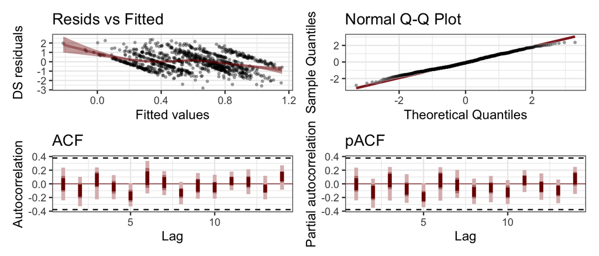

```r
plot(fit_trend_rw)
```

## Including dynamic components: coastal upwelling

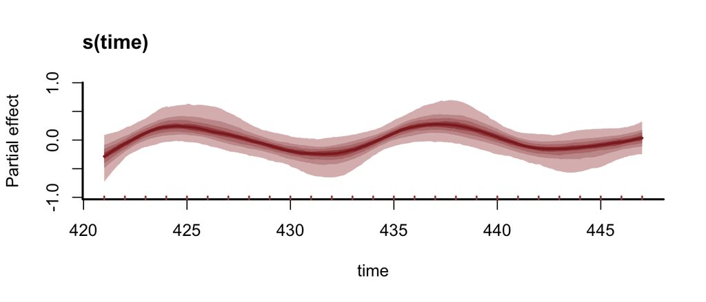

```r
plot_mvgam_smooth(fit_trend_rw)
```

## Including dynamic components: coastal upwelling

- Each of the trends (here for Latitude 31) is ~ flat

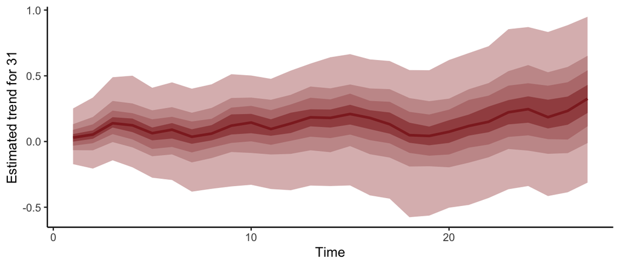

```r
plot_mvgam_trend(fit_trend_rw)
```

## Including dynamic components: coastal upwelling

- Some fits to forecasts are better – but training data actually seems worse

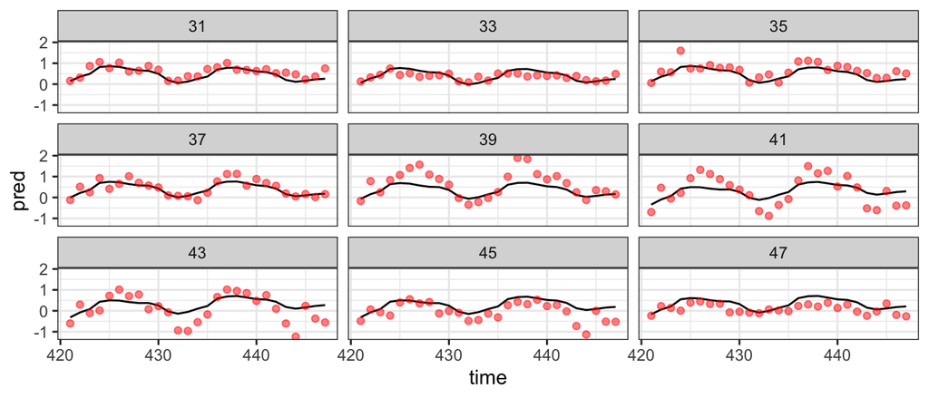

## Including dynamic components: coastal upwelling

```r
fit_trend_ar1 <- mvgam(cuti ~ s(time, bs="cr") +
               s(latitude, k=9, bs="re") +
                s(month, k = 12, bs="cc"),
             trend_model = 'AR1',
           data=cuti_long[cuti_long$year>2022,],
           share_obs_params = TRUE,
           family="gaussian", chains = 1)
```

## Including dynamic components: coastal upwelling

- Trends more flexible than the random walk appear to fit data a little better

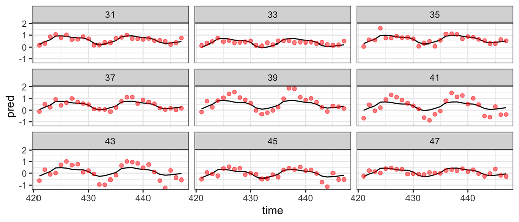

## Including dynamic components: coastal upwelling

- But maybe we’re trying to estimate too many trends
- Instead, model trends as dynamic factors (n = 2)

```r
fit_trend_fac <- mvgam(cuti ~ s(time, bs="cr") +
               s(latitude, k=9, bs="re") +
                s(month, k = 12, bs="cc"),
             trend_model = 'AR1',
             use_lv = TRUE,#<<,
             n_lv = 2,#<<,
           data=cuti_long[cuti_long$year>2022,],
           share_obs_params = TRUE,
           family="gaussian", chains = 1)
```

## Including dynamic components: coastal upwelling

- What do factors look like?
- By default mvdlm models these as AR1
- DFA model with AR1 trend + seasonal smooth

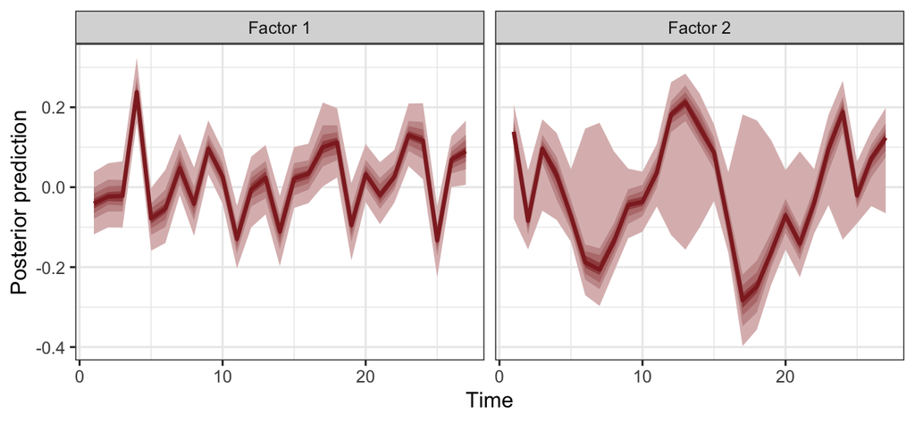

```r
plot(fit_trend_fac, type = 'factors')
```

## Including dynamic components: coastal upwelling

- What do loadings look like?

```r
pars <- rstan::extract(fit_trend_fac$model_output)
print(apply(pars$lv_coefs, c(2,3), mean))
```

[output not shown]

## Including dynamic components: coastal upwelling

- Factor model seems to be struggling (maybe more so in middle latitudes)
- Factors for this application probably not flexible enough

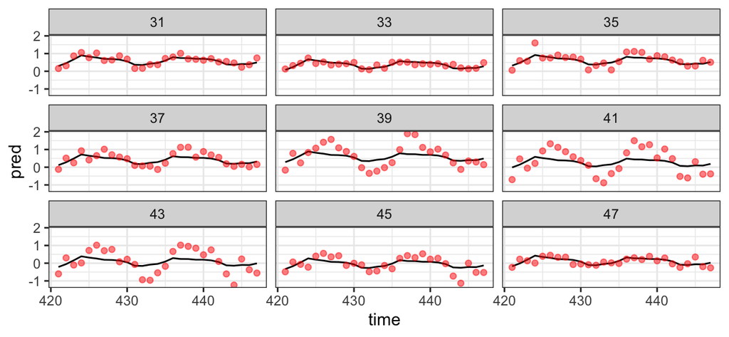

## Summary

- Multivariate models in `mgcv` allow for flexible modeling of multiple time series
- Factor smooths provide a way to relationships that differ across different levels of a factor
- `mvgam` extends this approach to include dynamic components, allowing for time-varying smooths and latent trends
- For time series DGAMs can be used to model temporal dependencies and nonlinear relationships in multivariate time series data

## Comparison with other approaches we’ve learned about

- All approaches have tradeoffs between fit to the training data and forecast error
- GAM fit and forecast error depends on the number of basis functions used (wiggliness)
- MARSS / DFA fit and forecast error depends on the number of factors and how they are modeled